# Module Trait Correlation

TigerZ

2023-5-4

在本教程中，我们介绍了如何将共表达模块与生物学和技术变量相关联。在开始本教程之前，请确保您已按照 [hdWGCNA basics](https://smorabit.github.io/hdWGCNA/articles/articles/basics_tutorial.html) 构建了共表达网络。

首先加载 snRNA-seq 数据和所需的库：

```r
# single-cell analysis package
library(Seurat)

# plotting and data science packages
library(tidyverse)
library(cowplot)
library(patchwork)

# co-expression network analysis packages:
library(WGCNA)
library(hdWGCNA)

# using the cowplot theme for ggplot
theme_set(theme_cowplot())

# 导入之前分析的结果
seurat_ref <- readRDS('hdWGCNA_object.rds')
```

# 1 Compute correlations

在这里，我们使用ModuleTraitCorrelation函数将选定的变量与模块特征基因相关联。该函数计算指定细胞分组的相关性，因为我们可以预期某些变量可能与某些细胞组中的某些模块相关，而在其他细胞组中则不相关。有某些类型的变量可以用于此分析，而其他变量则不应使用。

**Variables that can be used**

- 数值变量
- 仅有 2 个类别的分类变量，例如“对照组”和“条件组”。
- 具有顺序关系的分类变量。例如，您可能有一个“disease stage段”类别，按 “healthy”, “stage 1”, “stage 2”, “stage 3” 等顺序排列。在这种情况下，您必须确保该变量存储为 factor，并且级别设置得当。

**Variables that can not be used**

- 具有超过两个类别且不按顺序链接的分类变量。例如，假设您有一个数据集，其中包含三种转基因小鼠品系和一种对照品系。分类变量必须在运行相关性之前转换为数值，因此您最终会得到一个根本没有生物学意义的相关性，因为没有办法按照作为数值变量的意义来排序三种不同的品系。在这种情况下，您应该分别设置对照组和每个品系之间的成对相关性。我们通常有一个“Sample ID”变量，指示哪个细胞来自哪个样本，这是一个不一定按任何特定方式排序的变量，因此像这样的变量不适合 module-trait 相关性分析。

```r
# convert sex to factor
seurat_obj$msex <- as.factor(seurat_obj$msex)

# convert age_death to numeric
seurat_obj$age_death <- as.numeric(seurat_obj$age_death)

# list of traits to correlate
cur_traits <- c('braaksc', 'pmi', 'msex', 'age_death', 'doublet_scores', 'nCount_RNA', 'nFeature_RNA', 'total_counts_mt')

seurat_obj <- ModuleTraitCorrelation(
  seurat_obj,
  traits = cur_traits,
  group.by='cell_type'
)
```

对于所使用的任何类别变量，此函数都会打印出一条警告消息，告诉用户类别的排列顺序，以确保其合理。

## 1.1 Inspecting the output

我们可以运行函数 `GetModuleTraitCorrelation` 来检索该函数的输出。

```r
# get the mt-correlation results
mt_cor <- GetModuleTraitCorrelation(seurat_obj)

names(mt_cor)
```

```
[1] "cor"  "pval" "fdr"
```

`mt_cor` 是一个包含三个项目的列表；`cor`保存相关性结果，`pval`保存相关性p-values，`fdr`保存FDR校正后的p-values。

这些项目中的每一个都是一个列表，其中每个元素都是为执行的每个相关性测试的数据框。

```r
names(mt_cor$cor)
```

```
[1] "all_cells" "INH"       "EX"        "OPC"       "ODC"       "ASC"
[7] "MG"
```

```r
 head(mt_cor$cor$INH[,1:5])
```

```
                    INH-M1      INH-M2      INH-M3      INH-M4      INH-M5
braaksc         0.03870044 -0.09688440  0.03942469  0.02276098  0.02927256
pmi            -0.19875886  0.01922471  0.01987555  0.03446913  0.03078067
msex            0.10944994 -0.20587840 -0.02897015  0.05459526  0.03295336
age_death       0.10213951 -0.11556907 -0.11890340 -0.07049492 -0.03313401
doublet_scores  0.17624548  0.16632800  0.34830095 -0.21157291  0.02237719
nCount_RNA     -0.16869489  0.05340398  0.65516572  0.08221908 -0.06675538
```

# 2 Plot Correlation Heatmap

我们可以使用 `PlotModuleTraitCorrelation` 函数绘制相关性分析的结果。该函数为每个相关性矩阵创建一个单独的热图，然后使用 `patchwork` 将它们组合成一个图。

```
[1] "all_cells"
[1] "braaksc"         "pmi"             "msex"            "age_death"
[5] "doublet_scores"  "nCount_RNA"      "nFeature_RNA"    "total_counts_mt"
[1] "INH"
[1] "braaksc"         "pmi"             "msex"            "age_death"
[5] "doublet_scores"  "nCount_RNA"      "nFeature_RNA"    "total_counts_mt"
[1] "EX"
[1] "braaksc"         "pmi"             "msex"            "age_death"
[5] "doublet_scores"  "nCount_RNA"      "nFeature_RNA"    "total_counts_mt"
[1] "OPC"
[1] "braaksc"         "pmi"             "msex"            "age_death"
[5] "doublet_scores"  "nCount_RNA"      "nFeature_RNA"    "total_counts_mt"
[1] "ODC"
[1] "braaksc"         "pmi"             "msex"            "age_death"
[5] "doublet_scores"  "nCount_RNA"      "nFeature_RNA"    "total_counts_mt"
[1] "ASC"
[1] "braaksc"         "pmi"             "msex"            "age_death"
[5] "doublet_scores"  "nCount_RNA"      "nFeature_RNA"    "total_counts_mt"
[1] "MG"
[1] "braaksc"         "pmi"             "msex"            "age_death"
[5] "doublet_scores"  "nCount_RNA"      "nFeature_RNA"    "total_counts_mt"
```

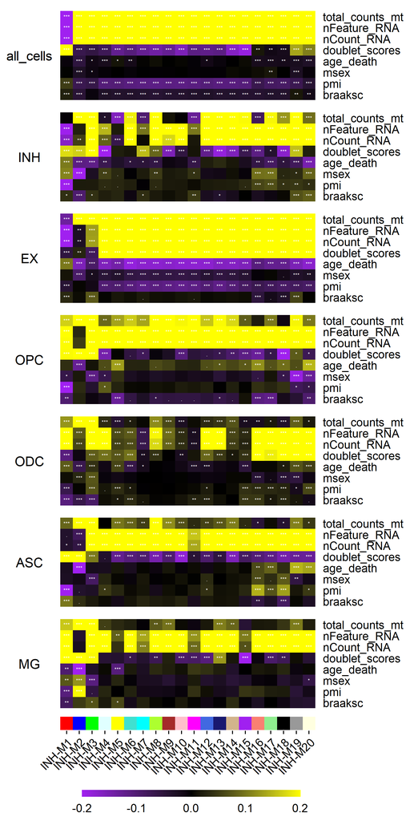

```r
PlotModuleTraitCorrelation(
  seurat_obj,
  label = 'fdr',
  label_symbol = 'stars',
  text_size = 2,
  text_digits = 2,
  text_color = 'white',
  high_color = 'yellow',
  mid_color = 'black',
  low_color = 'purple',
  plot_max = 0.2,
  combine=TRUE
)
```